# flux-model-comparison

2025-08-08

# OBJECTIVES

-In this tutorial, we will compare the tower FLUXNET tower data with the ELM output. There are 10 overlapping variables that we can compare between the two data sets. Check the “Crosswalk table” for these variables.

-There are 4 parts to this tutorial. Parts 1 to 3 will create time-series graphs for comparing environmental variables, energy exchange variables, and carbon flux variables. In Part 4, we use a simple tool to discern the level of agreement between flux tower data and ELM output.

# IMPORTANT NOTES

- This script needs access to Gmail to download the data from Google drive
- In each part, there is a “USER INPUT” section where you should change the variables to compare, units, conversion factors (refer to the crosswalk variable table), years of data, and graph title accordingly

-This tutorial is also used for comparing the adjusted and default simulations to flux tower data

#USER INPUT SECTION -change site name and URLs according to your study site

```r
# change to the ID of your study site here
site_name <- "US-Syv"

# flux tower data URL here (FLUXNET_SUBSET_DD file)
flux_url <- "https://drive.google.com/file/d/1kGu2JTe5afS_6ly9p3xgVFtTVtpmc__4/view?usp=drive_link"

# default ELM output URL here
elm_url <- "https://drive.google.com/file/d/1eCR99plnQQpqqQ0Y1h6YZlVA-8fBfgJ0/view?usp=drive_link"

# adjusted ELM output URL here
  elm_adj_url <- "https://drive.google.com/file/d/1eCR99plnQQpqqQ0Y1h6YZlVA-8fBfgJ0/view?usp=drive_link"

#starting year of flux tower data
start_year <- 2001

# Selected variables from ELM output to be compared with flux measurement
vars_to_extract <- c(
  "NEE",          # Net ecosystem exchange of carbon
  "GPP",          # Gross primary production
  "ER",           # Ecosystem respiration
  "TSOI_10CM",    # Soil temperature at 10 cm
  "FSH",          # Sensible heat flux
  "EFLX_LH_TOT",  # Total latent heat flux
  "TSA",          # surface air temperature
  "PBOT",         # atmospheric pressure
  "RAIN",         # Precipitation
  "FGR"           # Soil heat flux
)
```

# Read data from Google drive

```r
# You can download data from Google drive, if you have a Google mail account
library(googledrive)

# DOWNLOAD AND READ FLUX DATA
{
  file_id <- googledrive::as_id(flux_url)
  temp_file <- tempfile(fileext = ".csv") # Download the file to a temp location
  drive_download(file = file_id, path = temp_file, overwrite = TRUE)
  df.flux <- fread(temp_file)
  # covert -9999 to NA
  df.flux <- df.flux %>%
    mutate(across(everything(), ~na_if(. , -9999)))
  df.flux <- df.flux %>% # add more time variables
    mutate(
      TIMESTAMP = ymd(TIMESTAMP),
      year = year(TIMESTAMP),
      month = month(TIMESTAMP),
      date = as.Date(TIMESTAMP),
      doy = yday(TIMESTAMP)
    )
}
```

```
## ! Using an auto-discovered, cached token.
```

```
##   To suppress this message, modify your code or options to clearly consent to
##   the use of a cached token.
```

```
##   See gargle's "Non-interactive auth" vignette for more details:
```

```
## ℹ The googledrive package is using a cached token for
##   'yujie.ecology@gmail.com'.
```

```
## Auto-refreshing stale OAuth token.
```

```
## File downloaded:
```

```
## • 'AMF_US-Syv_FLUXNET_SUBSET_DD_2001-2023_4-6.csv'
##   <id: 1kGu2JTe5afS_6ly9p3xgVFtTVtpmc__4>
```

```
## Saved locally as:
```

```
## • 'C:\Users\yl763\AppData\Local\Temp\RtmpEdTiTT\file847c7d302883.csv'
```

```r
# DOWNLOAD AND READ DEFAULT ELM OUTPUT
{
  # Google Drive URL for the .nc file
  nc_file_id <- as_id(elm_url)
  temp_nc_file <- tempfile(fileext = ".nc") # Define temporary download path
  drive_download(file = nc_file_id, path = temp_nc_file, overwrite = TRUE) # Download the file
  nc <- nc_open(temp_nc_file) # Open the NetCDF file


  # Extract time (mcdate)
  mcdate <- ncvar_get(nc, "mcdate")
  data_list <- lapply(vars_to_extract, function(var) ncvar_get(nc, var))

  # Combine into data frame
  df.model <- data.frame(mcdate = mcdate)
  for (i in seq_along(vars_to_extract)) {
    df.model[[vars_to_extract[i]]] <- data_list[[i]]
  }

  # Close NetCDF file
  nc_close(nc)

  # modify time variables
  df.model <- df.model %>%
    mutate(
      mcdate = ymd(mcdate),
      year = year(mcdate),
      month = month(mcdate),
      date = as.Date(mcdate),
      doy = yday(mcdate)
    ) %>%
    rename(TIMESTAMP = mcdate)
}
```

```
## File downloaded:
```

```
## • 'ELM_output_US_Syv.nc' <id: 1eCR99plnQQpqqQ0Y1h6YZlVA-8fBfgJ0>
```

```
## Saved locally as:
```

```
## • 'C:\Users\yl763\AppData\Local\Temp\RtmpEdTiTT\file847c5b4736ef.nc'
```

```r
# DOWNLOAD AND READ ADJUSTED ELM OUTPUT
{
  nc_adj_file_id <- as_id(elm_adj_url)
  temp_nc_adj_file <- tempfile(fileext = ".nc") # Define temporary download path
  drive_download(file = nc_adj_file_id, path = temp_nc_adj_file, overwrite = TRUE) # Download the file
  nc_adj <- nc_open(temp_nc_adj_file) # Open the NetCDF file


  # Extract time (mcdate)
  mcdate <- ncvar_get(nc_adj, "mcdate")
  data_list <- lapply(vars_to_extract, function(var) ncvar_get(nc_adj, var))

  # Combine into data frame
  df.model_adj <- data.frame(mcdate = mcdate)
  for (i in seq_along(vars_to_extract)) {
    df.model_adj[[vars_to_extract[i]]] <- data_list[[i]]
  }

  # Close NetCDF file
  nc_close(nc_adj)

  # modify time variables
  df.model_adj <- df.model_adj %>%
    mutate(
      mcdate = ymd(mcdate),
      year = year(mcdate),
      month = month(mcdate),
      date = as.Date(mcdate),
      doy = yday(mcdate)
    ) %>%
    rename(TIMESTAMP = mcdate)
}
```

```
## File downloaded:
```

```
## • 'ELM_output_US_Syv.nc' <id: 1eCR99plnQQpqqQ0Y1h6YZlVA-8fBfgJ0>
```

```
## Saved locally as:
```

```
## • 'C:\Users\yl763\AppData\Local\Temp\RtmpEdTiTT\file847c518c1ca6.nc'
```

```r
# combine flux data and model output
df.model = df.model[df.model$year >= start_year, ] # please change to the start year of flux measurement for you study site
df.model_adj = df.model_adj[df.model_adj$year >= start_year, ] # please change to the start year of flux measurement for you study site
df.model_adj <- df.model_adj %>%
  rename_with(~ paste0(., "_adj"), .cols = -TIMESTAMP)
df.combined <- df.model %>%
  left_join(df.flux, by = "TIMESTAMP") %>%
  left_join(df.model_adj, by = "TIMESTAMP")
names(df.combined)
```

```
##   [1] "TIMESTAMP"           "NEE"                 "GPP"
##   [4] "ER"                  "TSOI_10CM"           "FSH"
##   [7] "EFLX_LH_TOT"         "TSA"                 "PBOT"
##  [10] "RAIN"                "FGR"                 "year.x"
##  [13] "month.x"             "date.x"              "doy.x"
##  [16] "TA_F"                "TA_F_QC"             "SW_IN_POT"
##  [19] "SW_IN_F"             "SW_IN_F_QC"          "LW_IN_F"
##  [22] "LW_IN_F_QC"          "VPD_F"               "VPD_F_QC"
##  [25] "PA_F"                "PA_F_QC"             "P_F"
##  [28] "P_F_QC"              "WS_F"                "WS_F_QC"
##  [31] "USTAR"               "USTAR_QC"            "NETRAD"
##  [34] "NETRAD_QC"           "PPFD_IN"             "PPFD_IN_QC"
##  [37] "CO2_F_MDS"           "CO2_F_MDS_QC"        "TS_F_MDS_1"
##  [40] "TS_F_MDS_2"          "TS_F_MDS_3"          "TS_F_MDS_4"
##  [43] "TS_F_MDS_5"          "TS_F_MDS_1_QC"       "TS_F_MDS_2_QC"
```

[output cut: 24 more lines]

#PART 1: Comparison of environmental variables between flux tower and ELM data

- The example here is currently set for comparing air temperature
- Use the crosswalk table for the variable names, units, and conversion factors

```r
# ===== USER INPUT SECTION ====================================================
flux_var <- "TA_F"     # Flux variable name
model_var <- "TSA"     # Model variable name
convert_model_units <- function(x) x - 273.15  # Set equation if needed

selected_years <- list(2001:2015) #change years to plot; it can handle several batches (ex: list(2001:2005, 2010:20015))

compare_name <- "Air Temperature"   # variable being compared
flux_label <- expression(AirTemp[flux]~(degC)) #change label name and units as needed
model_label <- expression(AirTemp[model]~(degC)) #change label name and units as needed
plot_title <- "Air Temp Comparison" #change plot title as needed
time_series_label <- expression(AirTemp~(degC)) # change label name and units as needed


# =============================================================================
```

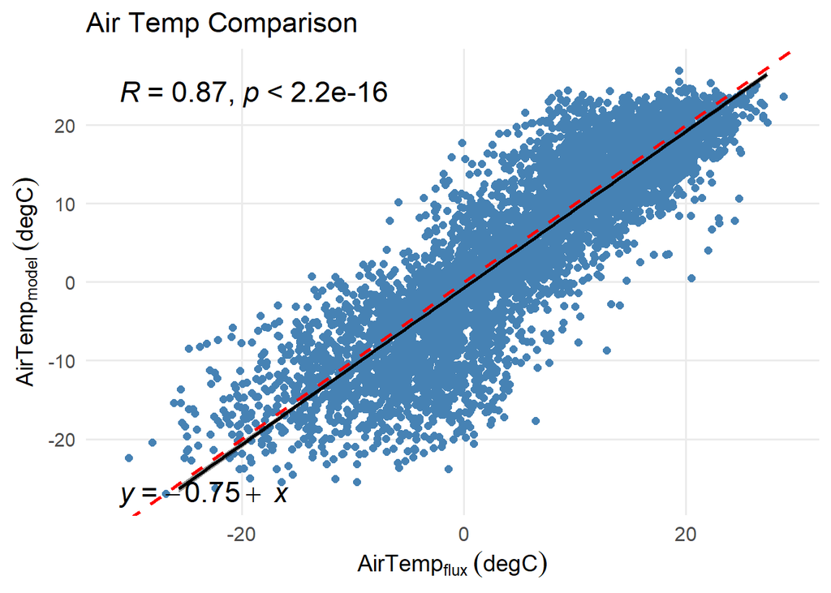

```r
year_range <- unlist(selected_years)

# ==== Derived comparison columns ====
flux_col <- paste0(compare_name, "_flux")
model_col <- paste0(compare_name, "_model")

df.combined_new <- df.combined %>%
  mutate(
    !!flux_col := .data[[flux_var]],
    !!model_col := convert_model_units(.data[[model_var]])
  ) %>%
  filter(year.x %in% year_range)

# ==== Dynamic axis limits for scatter plot ====
x_vals <- df.combined_new[[flux_var]]
y_vals <- convert_model_units(df.combined_new[[model_var]])
x_limits <- c(floor(min(x_vals, na.rm = TRUE)), ceiling(max(x_vals, na.rm = TRUE)))
y_limits <- c(floor(min(y_vals, na.rm = TRUE)), ceiling(max(y_vals, na.rm = TRUE)))

# ==== X-Y SCATTER PLOT ====
ggscatter(
  data = df.combined_new,
  x = flux_col,
  y = model_col,
  color = "steelblue",
  add = "reg.line",
  add.params = list(color = "black", size = 1),
  conf.int = TRUE,
  cor.coef = TRUE,
  cor.coeff.args = list(size = 6),
  label.x = x_limits[1],
  label.y = y_limits[2],
  title = plot_title,
  ggtheme = theme_pubr()
) +
  stat_regline_equation(
    aes(label = ..eq.label..),
    label.x = x_limits[1] ,
    label.y = y_limits[1],
    size = 6
  ) +
  geom_abline(slope = 1, intercept = 0, color = "red", linetype = "dashed", size = 1) +
  xlim(x_limits) + ylim(y_limits) +
  xlab(flux_label) + ylab(model_label) +
  my_theme
```

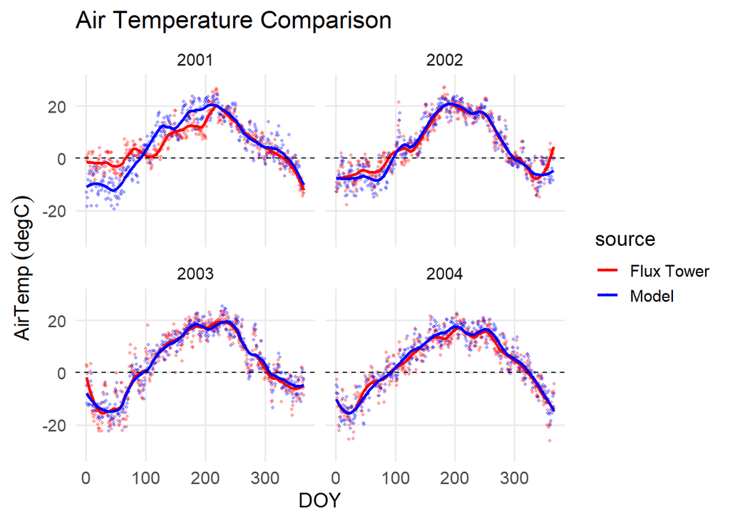

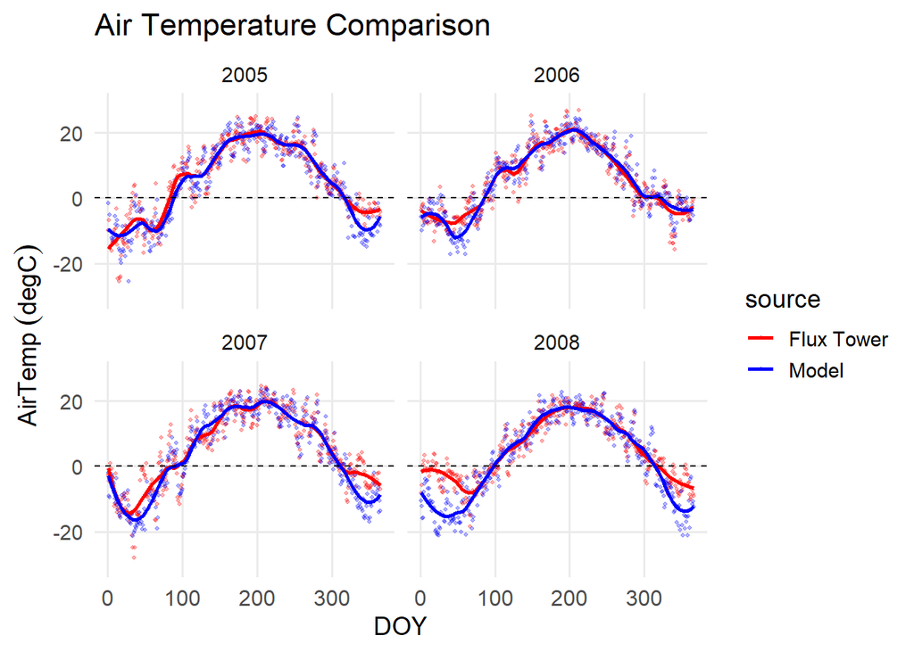

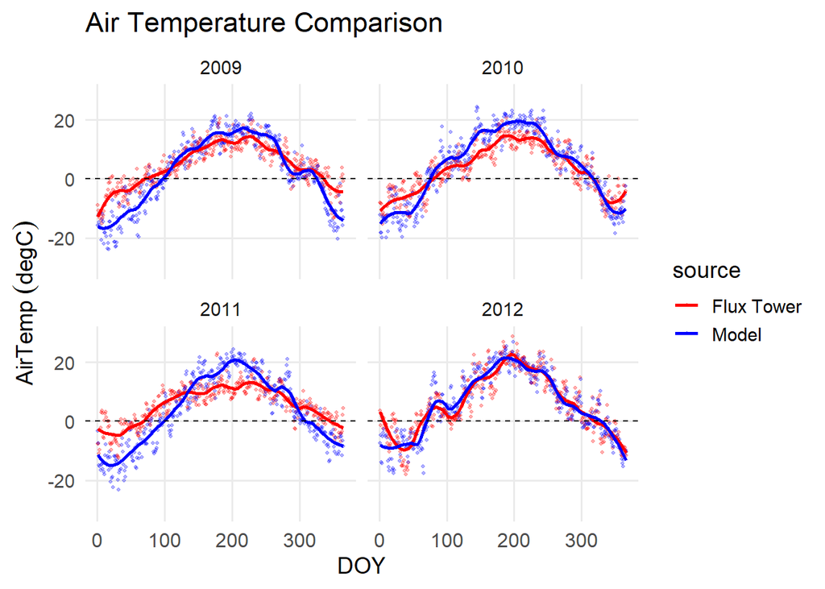

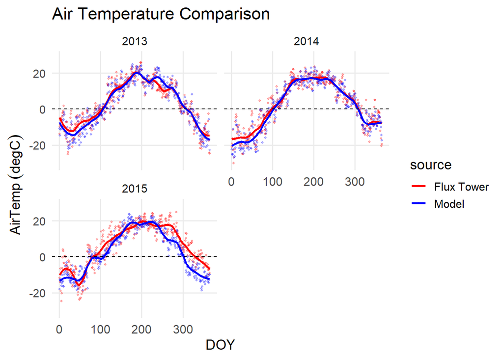

```r
# ==== TIME SERIES PLOT ====
# Pivot to long format
df_long <- df.combined_new %>%
  pivot_longer(
    cols = all_of(c(flux_col, model_col)),
    names_to = "source",
    values_to = compare_name
  ) %>%
  filter(year.x %in% year_range)

# ==== Dynamic axis limits for scatter plot ====
y_vals <- df.combined_new[[flux_var]]
y_limits <- c(floor(min(y_vals, na.rm = TRUE)), ceiling(max(y_vals, na.rm = TRUE)))


all_years <- sort(unique(df_long$year.x))
for (i in seq(1, length(all_years), by = 4)) {
  years_to_plot <- all_years[i:min(i+3, length(all_years))]
  df_subset <- df_long %>% filter(year.x %in% years_to_plot)

  p <- ggplot(df_subset, aes(x = doy.x, y = .data[[compare_name]], color = source)) +
    geom_point(alpha = 0.3, size = 0.7) +
    geom_smooth(se = FALSE, method = "loess", span = 0.2) +
    geom_hline(yintercept = 0, linetype = "dashed") +
    facet_wrap(~ year.x, ncol = 2) +
    xlab("DOY") +
    ylab(time_series_label) +
    scale_color_manual(
      values = setNames(c("red", "blue"), c(flux_col, model_col)),
      labels = c("Flux Tower", "Model")
    ) +
   ylim(y_limits) +
    labs(title = paste0(compare_name, " Comparison")) +
    my_theme

  print(p)  # or ggsave() to save each plot
}
```

# PART 2: Energy exchange variables comparison between flux tower and ELM data

```r
# ===== USER INPUT SECTION ====================================================
flux_var <- "LE_F_MDS"     # Flux variable name
model_var <- "EFLX_LH_TOT"     # Model variable name
convert_model_units <- function(x) x  # Set equation if needed

selected_years <- list(2001:2015) #change years to plot; it can handle several batches (ex: list(2001:2005, 2010:20015))

compare_name <- "Latent heat flux"   # variable being compared
flux_label <- expression(LE[flux]~(W/m^2)) #change label name and units as needed
model_label <- expression(LE[model]~(W/m^2)) #change label name and units as needed
plot_title <- "Latent Heat Flux Comparison" #change plot title as needed
time_series_label <- expression(LE_flux~(W/m^2)) # change label name and units as needed


# =============================================================================
```

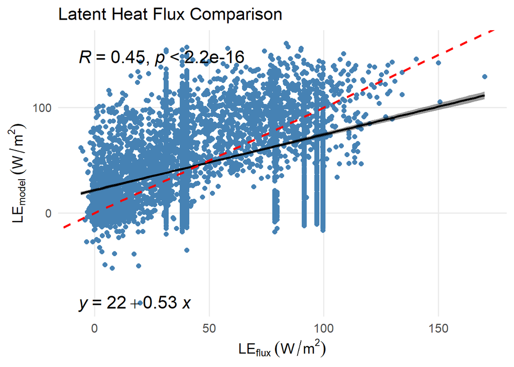

```r
year_range <- unlist(selected_years)

# ==== Derived comparison columns ====
flux_col <- paste0(compare_name, "_flux")
model_col <- paste0(compare_name, "_model")

df.combined_new <- df.combined %>%
  mutate(
    !!flux_col := .data[[flux_var]],
    !!model_col := convert_model_units(.data[[model_var]])
  ) %>%
  filter(year.x %in% year_range)

# ==== Dynamic axis limits for scatter plot ====
x_vals <- df.combined_new[[flux_var]]
y_vals <- convert_model_units(df.combined_new[[model_var]])
x_limits <- c(floor(min(x_vals, na.rm = TRUE)), ceiling(max(x_vals, na.rm = TRUE)))
y_limits <- c(floor(min(y_vals, na.rm = TRUE)), ceiling(max(y_vals, na.rm = TRUE)))

# ==== X-Y SCATTER PLOT ====
ggscatter(
  data = df.combined_new,
  x = flux_col,
  y = model_col,
  color = "steelblue",
  add = "reg.line",
  add.params = list(color = "black", size = 1),
  conf.int = TRUE,
  cor.coef = TRUE,
  cor.coeff.args = list(size = 6),
  label.x = x_limits[1],
  label.y = y_limits[2],
  title = plot_title,
  ggtheme = theme_pubr()
) +
  stat_regline_equation(
    aes(label = ..eq.label..),
    label.x = x_limits[1] ,
    label.y = y_limits[1],
    size = 6
  ) +
  geom_abline(slope = 1, intercept = 0, color = "red", linetype = "dashed", size = 1) +
  xlim(x_limits) + ylim(y_limits) +
  xlab(flux_label) + ylab(model_label) +
  my_theme
```

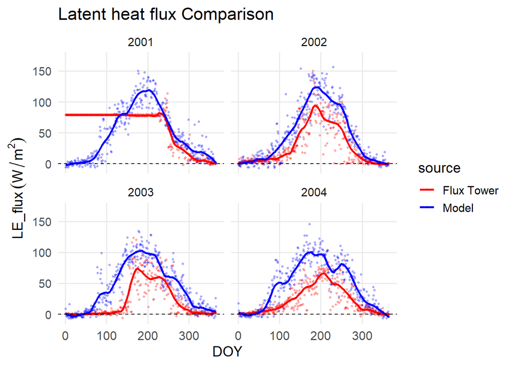

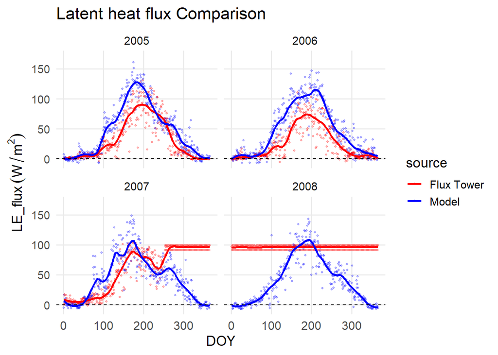

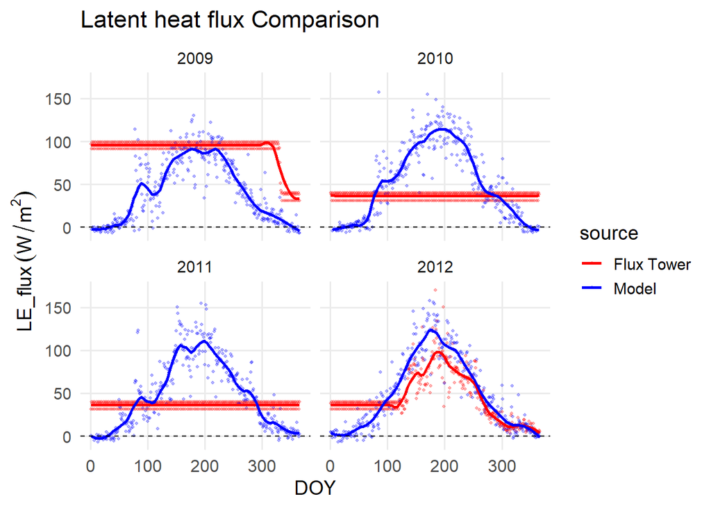

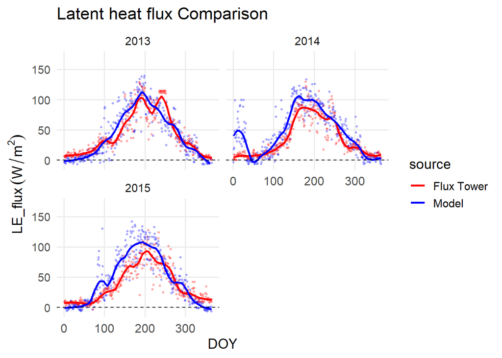

```r
# ==== TIME SERIES PLOT ====
# Pivot to long format
df_long <- df.combined_new %>%
  pivot_longer(
    cols = all_of(c(flux_col, model_col)),
    names_to = "source",
    values_to = compare_name
  ) %>%
  filter(year.x %in% year_range)

# ==== Dynamic axis limits for scatter plot ====
y_vals <- df.combined_new[[flux_var]]
y_limits <- c(floor(min(y_vals, na.rm = TRUE)), ceiling(max(y_vals, na.rm = TRUE)))


all_years <- sort(unique(df_long$year.x))
for (i in seq(1, length(all_years), by = 4)) {
  years_to_plot <- all_years[i:min(i+3, length(all_years))]
  df_subset <- df_long %>% filter(year.x %in% years_to_plot)

  p <- ggplot(df_subset, aes(x = doy.x, y = .data[[compare_name]], color = source)) +
    geom_point(alpha = 0.3, size = 0.7) +
    geom_smooth(se = FALSE, method = "loess", span = 0.2) +
    geom_hline(yintercept = 0, linetype = "dashed") +
    facet_wrap(~ year.x, ncol = 2) +
    xlab("DOY") +
    ylab(time_series_label) +
    scale_color_manual(
      values = setNames(c("red", "blue"), c(flux_col, model_col)),
      labels = c("Flux Tower", "Model")
    ) +
   ylim(y_limits) +
    labs(title = paste0(compare_name, " Comparison")) +
    my_theme

  print(p)  # or ggsave() to save each plot
}
```

# PART 3: Carbon Flux variables comparison between flux tower and ELM data

```r
# ===== USER INPUT SECTION ====================================================
flux_var <- "NEE_VUT_REF"     # Flux variable name
model_var <- "NEE"     # Model variable name
convert_model_units <- function(x) x * 86400 # Set equation if needed

selected_years <- list(2001:2015) #change years to plot; it can handle several batches (ex: list(2001:2005, 2010:20015))

compare_name <- "Net Ecosystem Exchange"   # variable being compared
flux_label <- expression(NEE[flux]~(gC/m^2/day)) #change label name and units as needed
model_label <- expression(NEE[model]~(gC/m^2/day)) #change label name and units as needed
plot_title <- "NEE Comparison" #change plot title as needed
time_series_label <- expression(NEE~(gC/m^2/day)) # change label name and units as needed


# =============================================================================
```

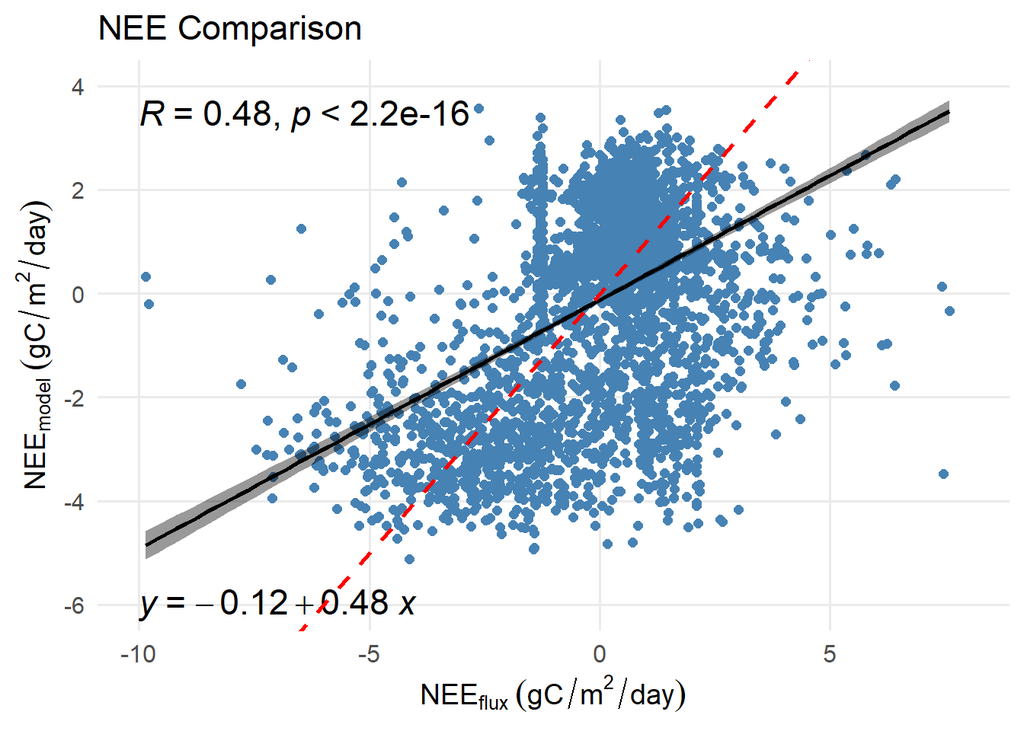

```r
year_range <- unlist(selected_years)

# ==== Derived comparison columns ====
flux_col <- paste0(compare_name, "_flux")
model_col <- paste0(compare_name, "_model")

df.combined_new <- df.combined %>%
  mutate(
    !!flux_col := .data[[flux_var]],
    !!model_col := convert_model_units(.data[[model_var]])
  ) %>%
  filter(year.x %in% year_range)

# ==== Dynamic axis limits for scatter plot ====
x_vals <- df.combined_new[[flux_var]]
y_vals <- convert_model_units(df.combined_new[[model_var]])
x_limits <- c(floor(min(x_vals, na.rm = TRUE)), ceiling(max(x_vals, na.rm = TRUE)))
y_limits <- c(floor(min(y_vals, na.rm = TRUE)), ceiling(max(y_vals, na.rm = TRUE)))

# ==== X-Y SCATTER PLOT ====
ggscatter(
  data = df.combined_new,
  x = flux_col,
  y = model_col,
  color = "steelblue",
  add = "reg.line",
  add.params = list(color = "black", size = 1),
  conf.int = TRUE,
  cor.coef = TRUE,
  cor.coeff.args = list(size = 6),
  label.x = x_limits[1],
  label.y = y_limits[2],
  title = plot_title,
  ggtheme = theme_pubr()
) +
  stat_regline_equation(
    aes(label = ..eq.label..),
    label.x = x_limits[1] ,
    label.y = y_limits[1],
    size = 6
  ) +
  geom_abline(slope = 1, intercept = 0, color = "red", linetype = "dashed", size = 1) +
  xlim(x_limits) + ylim(y_limits) +
  xlab(flux_label) + ylab(model_label) +
  my_theme
```

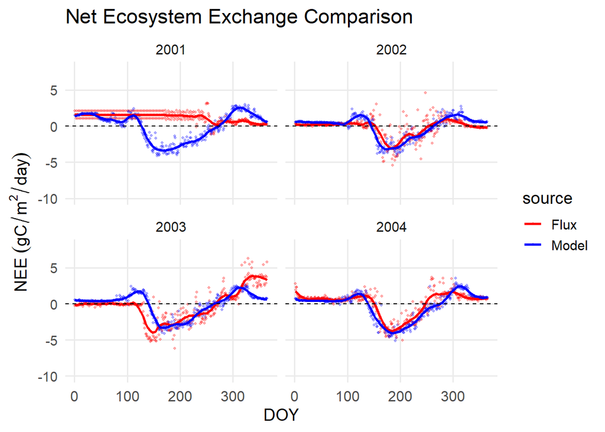

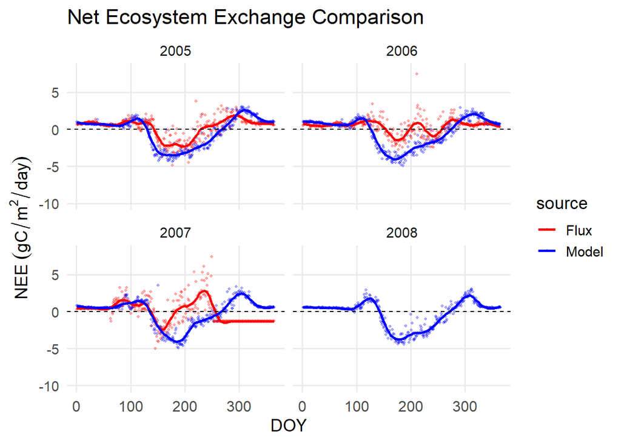

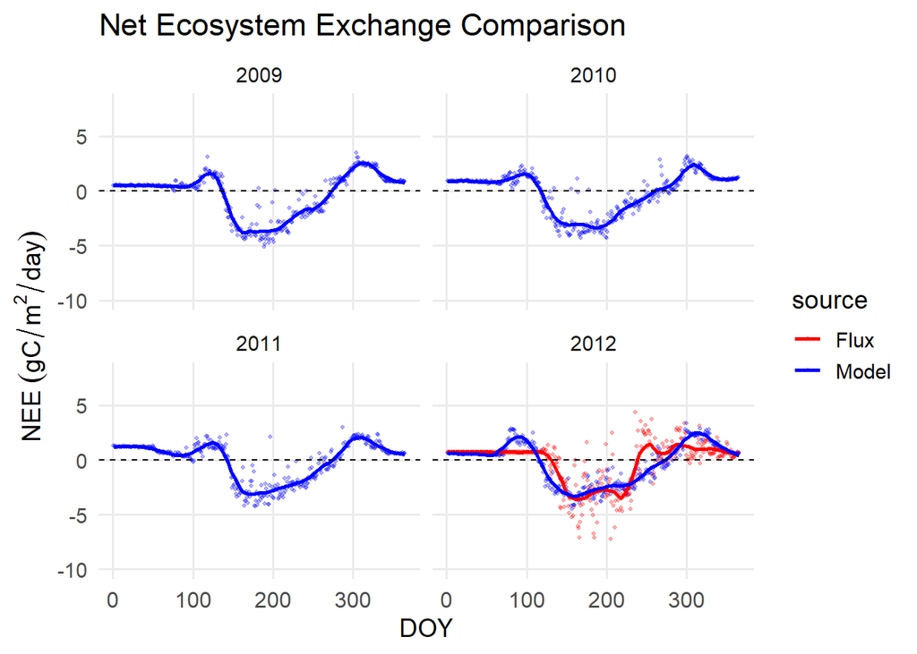

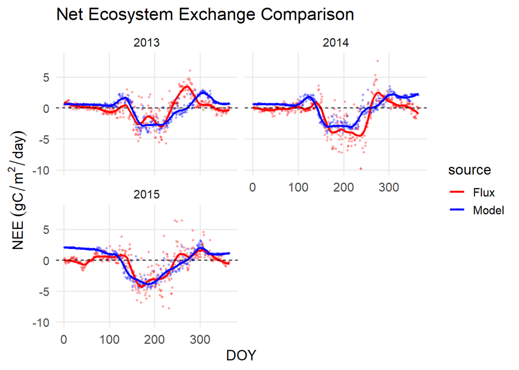

```r
# ==== TIME SERIES PLOT ====
# Pivot to long format
df_long <- df.combined_new %>%
  pivot_longer(
    cols = all_of(c(flux_col, model_col)),
    names_to = "source",
    values_to = compare_name
  ) %>%
  filter(year.x %in% year_range)

# ==== Dynamic axis limits for scatter plot ====
y_vals <- df.combined_new[[flux_var]]
y_limits <- c(floor(min(y_vals, na.rm = TRUE)), ceiling(max(y_vals, na.rm = TRUE)))


all_years <- sort(unique(df_long$year.x))
for (i in seq(1, length(all_years), by = 4)) {
  years_to_plot <- all_years[i:min(i+3, length(all_years))]
  df_subset <- df_long %>% filter(year.x %in% years_to_plot)

  p <- ggplot(df_subset, aes(x = doy.x, y = .data[[compare_name]], color = source)) +
    geom_point(alpha = 0.3, size = 0.7) +
    geom_smooth(se = FALSE, method = "loess", span = 0.2) +
    geom_hline(yintercept = 0, linetype = "dashed") +
    facet_wrap(~ year.x, ncol = 2) +
    xlab("DOY") +
    ylab(time_series_label) +
    scale_color_manual(
      values = setNames(c("red", "blue"), c(flux_col, model_col)),
      labels = c("Flux", "Model")
    ) +
   ylim(y_limits) +
    labs(title = paste0(compare_name, " Comparison")) +
    my_theme

  print(p)  # or ggsave() to save each plot
}
```

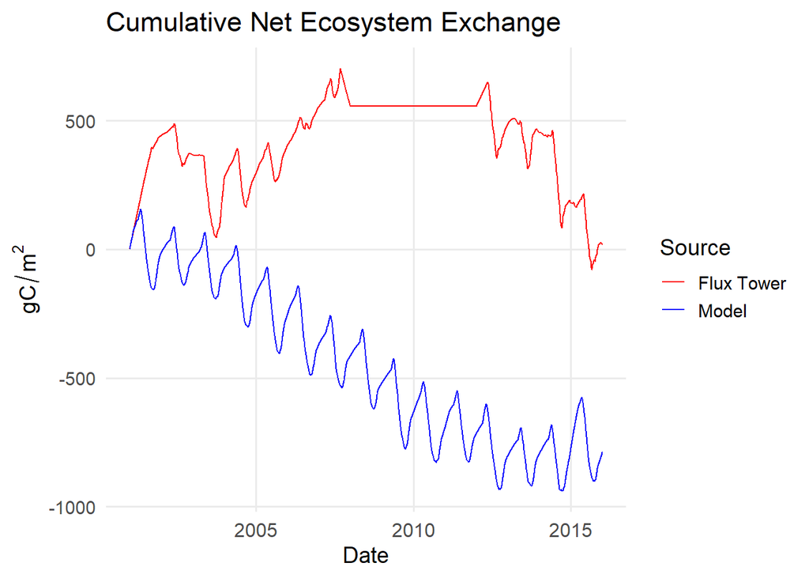

```r
## Cumulative Fluxes
df.cumulative <- df.combined_new %>%
  arrange(TIMESTAMP) %>%
  mutate(
    cum_flux = cumsum(replace_na(.data[[flux_col]], 0)),
    cum_model = cumsum(replace_na(.data[[model_col]], 0))
  )


# Create cumulative sum data
df_cumsum <- df.combined_new %>%
  select(TIMESTAMP, year.x, doy.x, all_of(c(flux_col, model_col))) %>%
  pivot_longer(
    cols = all_of(c(flux_col, model_col)),
    names_to = "source",
    values_to = "value"
  ) %>%
  group_by(year.x, source) %>%
  arrange(doy.x, .by_group = TRUE) %>%
  mutate(cumulative_value = cumsum(replace_na(value, 0))) %>%
  ungroup()

# Plot cumulative sum for all years
ggplot(df.cumulative, aes(x = TIMESTAMP)) +
  geom_line(aes(y = cum_flux, color = "Flux Tower")) +
  geom_line(aes(y = cum_model, color = "Model")) +
  labs(
    title = paste0("Cumulative ", compare_name),
    x = "Date",
    y = expression(gC/m^2),
    color = "Source"
  ) +
  scale_color_manual(values = c("Flux Tower" = "red", "Model" = "blue")) +
  my_theme
```

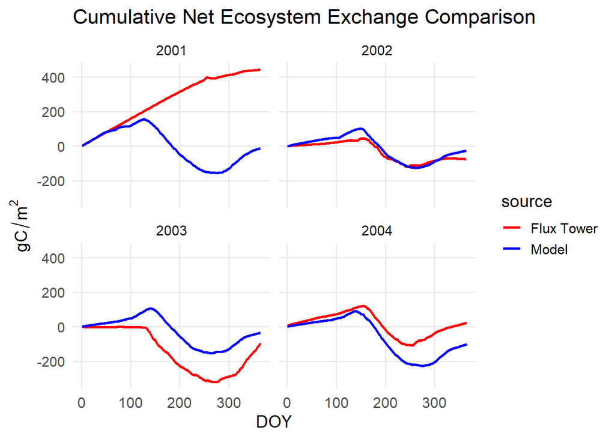

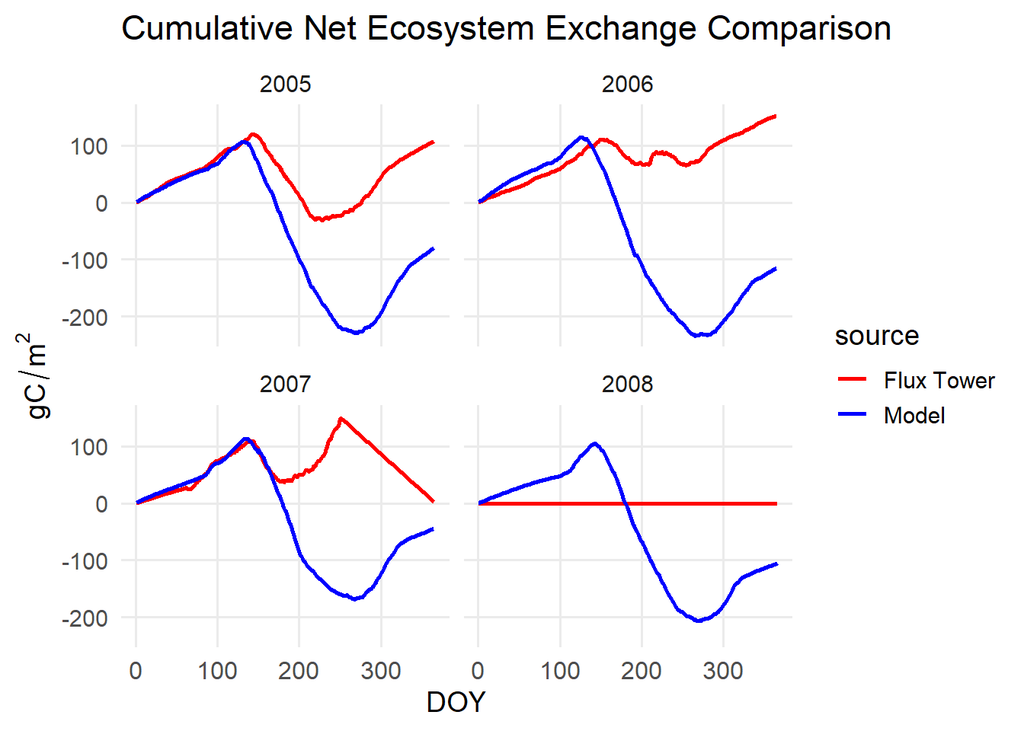

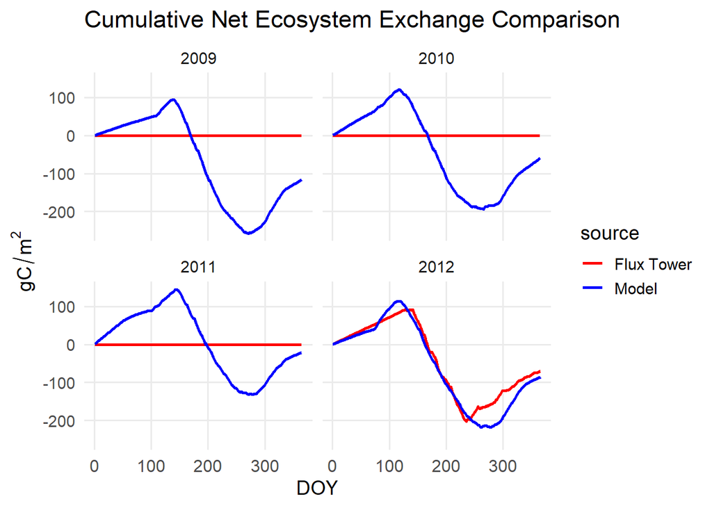

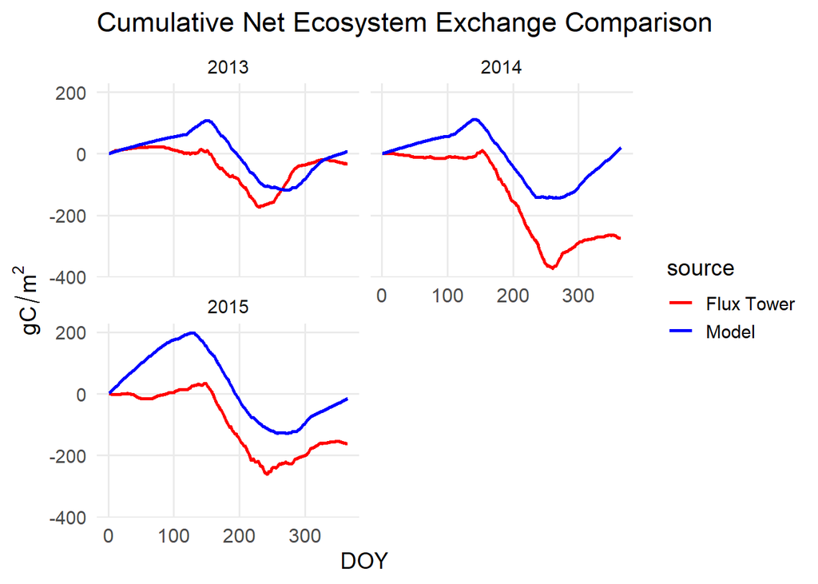

```r
# Cumulative sum plot in chunks of 4 years
for (i in seq(1, length(all_years), by = 4)) {
  years_to_plot <- all_years[i:min(i+3, length(all_years))]
  df_subset <- df_cumsum %>% filter(year.x %in% years_to_plot)

  p_cumsum <- ggplot(df_subset, aes(x = doy.x, y = cumulative_value, color = source)) +
    geom_line(size = 1) +
    facet_wrap(~ year.x, ncol = 2) +
    xlab("DOY") +
    ylab(expression(gC/m^2)) +
    scale_color_manual(
      values = setNames(c("red", "blue"), c(flux_col, model_col)),
      labels = c("Flux Tower", "Model")
    ) +
    labs(title = paste0("Cumulative ", compare_name, " Comparison")) +
    my_theme

  print(p_cumsum)
}
```

# PART 4: Evaluating level of agreement

NOTE: this is a simplified approach that evaluates model-data agreement assuming model and flux tower data are from a single point, per year, and over the entire period that data is available for both. This means that there aren’t spatial components to the evaluation.

```r
# ===== USER INPUT SECTION ====================================================
nee_flux <- "NEE_VUT_REF"
nee_model <- "NEE"
nee <- "NEE"
gpp_flux <- "GPP_NT_VUT_REF"
gpp_model <- "GPP"
reco_flux <- "RECO_NT_VUT_REF"
reco_model <- "ER"

selected_years <- list(2001:2015) #change years to plot; it can handle several batches (ex: list(2001:2005, 2010:20015))
# =============================================================================
```

```r
year_range <- unlist(selected_years)


df.combined_eval <- df.combined %>%
  mutate(
    # Apply actual values from variables
    NEE_flux = .data[[nee_flux]],
    NEE_model = .data[[nee_model]] * 86400,  # Convert from µmol/m²/s to gC/m²/day

    GPP_flux = .data[[gpp_flux]],
    GPP_model = .data[[gpp_model]] * 86400,  # Unit conversion if needed

    Reco_flux = .data[[reco_flux]],
    Reco_model = .data[[reco_model]] * 86400
  ) %>%
  filter(year.x %in% year_range)


variables_compare <- c("year.x", "month.x", "date.x", "doy.x", "TIMESTAMP", "NEE_flux", "NEE_model",
                       "GPP_flux", "GPP_model", "Reco_flux", "Reco_model")
setDT(df.combined_eval)  # convert in-place
df.combined_sub = df.combined_eval[, ..variables_compare]

#replace negative tower GPP values w/NA for now
df.combined_sub$GPP_flux[df.combined_sub$GPP_flux < 0] <- NA


df.combined_sub <- df.combined_sub %>%
  pivot_longer(cols = c(NEE_flux, NEE_model, GPP_flux, GPP_model, Reco_flux, Reco_model),
             names_to = "variable",
             values_to = "value")

df.combined_sub <- df.combined_sub %>%
  mutate(data_type = case_when(variable == "NEE_flux" ~ "Tower",
                               variable == "NEE_model" ~ "Model",
                               variable == "GPP_flux" ~ "Tower",
                               variable == "GPP_model" ~ "Model",
                               variable == "Reco_flux" ~ "Tower",
                               variable == "Reco_model" ~ "Model"))

df.combined_sub <- df.combined_sub %>%
  mutate(flux_type = case_when(variable == "NEE_flux" ~ "NEE",
                               variable == "NEE_model" ~ "NEE",
                               variable == "GPP_flux" ~ "GPP",
                               variable == "GPP_model" ~ "GPP",
                               variable == "Reco_flux" ~ "Reco",
                               variable == "Reco_model" ~ "Reco"))

df.combined_sub$site_name <- site_name

## filter data

 #filtering out dates where there isn't tower data available for comparison
# Identify dates where Tower data is missing for each flux_type
missing_dates <- df.combined_sub %>%
  filter(data_type == "Tower") %>%
  filter(is.na(value)) %>%
  select(date.x, flux_type)

# Remove all rows for those dates and flux_type combos
df.combined_sub <- df.combined_sub %>%
  anti_join(missing_dates, by = c("date.x", "flux_type"))

## compute interannual and overall metrics, then plot it

# Variables to evaluate
variable_list <- c("GPP", "NEE", "Reco")
all_metrics <- list()  # to store results

years_to_evaluate <- sort(unique(df.combined_sub$year.x))

for (variable_run in variable_list) {
  for (year_val in years_to_evaluate) {

  # Subset model and observation data
  model <- subset(df.combined_sub, data_type == "Model" & flux_type == variable_run & year.x == year_val)
  obs <- subset(df.combined_sub, data_type == "Tower" & flux_type == variable_run & year.x == year_val)


  # Skip if data is missing
    if (nrow(model) == 0 || nrow(obs) == 0 || all(is.na(model$value)) || all(is.na(obs$value))) next

  norm_sd <- sd(model$value, na.rm = TRUE) / sd(obs$value, na.rm = TRUE)

  # Correlation score -- tells us if the model gets the general temporal pattern right
  S_corr <- (1 + cor(model$value, obs$value, use = "complete.obs", method = "pearson")) / 2

  # Bias and bias score -- tells us if the model consistently over or underestimates
  bias <- model$value - obs$value #pointwise
  # regular rmse
  rmse <- sqrt(mean((model$value - obs$value)^2, na.rm = TRUE))

  #nondimensionalize bias as a relative error, account for cases where you might be dividing by 0 b/c obs values could be 0
  e_bias <- ifelse(
    abs(obs$value) > 0,
    abs(model$value - obs$value) / abs(obs$value),
    NA)

  S_bias <- exp(-1 * e_bias)

  S_bias[!is.finite(S_bias)] <- NA

  domain_S_bias <- mean(S_bias, na.rm = TRUE)

  # RMSE and RMSE score -- tells us how well the amplitude and variability match (this approach controls for double-counting bias by using centralized rmse)
  #This implementation assumes no spatial structure (i.e., it’s a single grid cell or averaged across an area of interest).
  #If you're computing this per grid cell in a spatial array, you'd apply it per column or group
  #This approach removes bias before computing RMSE, so the RMSE score focuses on variance differences rather than
  #systematic offset, and so bias doesn't get essentially 'double counted' in the overall score
  #first need to centralize (remove mean) the timeseries

  model_anom <- model$value - mean(model$value, na.rm=T)
  obs_anom <- obs$value - mean(obs$value, na.rm=T)

  #then compute centralized rmse
  n <- length(obs_anom)

  crmse <- sqrt(mean((model_anom - obs_anom)^2, na.rm=T))

  #and compute centralized RMS of reference obs (crms)
  crms <- sqrt(mean(obs_anom^2, na.rm = TRUE))

  # calculate relative error
  e_rmse <- crmse / crms
  S_rmse <- exp(-1 * e_rmse)

  # Overall score
  S <- (domain_S_bias + 2 * S_rmse + S_corr) / 4

  # Skip if all metrics are NA
  if (is.na(S)) next

  # Summary metrics
  metric <- c("tower mean", "tower SD","model mean", "model SD", "SD norm.", "bias", "RMSE",
              "correlation score", "bias score", "RMSE score", "overall score")

  model_scores <- c(mean(obs$value, na.rm = TRUE), sd(obs$value, na.rm = TRUE),
                      mean(model$value, na.rm = TRUE), sd(model$value, na.rm = TRUE),
                      norm_sd, mean(bias, na.rm = TRUE), rmse,
                      S_corr, domain_S_bias, S_rmse, S)


  score_df <- data.frame(site = site_name, year = year_val, variable = variable_run, metric = metric, value = model_scores)

  all_metrics[[paste0(variable_run, "_", year_val)]] <- score_df
  }
}
# Combine results from loop and create interannual metric table
metric_df <- do.call(rbind, all_metrics)
row.names(metric_df) <- NULL

print(metric_df) #check out the results!
```

```
##       site year variable            metric        value
## 1   US-Syv 2001      GPP        tower mean  2.998368372
## 2   US-Syv 2001      GPP          tower SD  2.437734507
## 3   US-Syv 2001      GPP        model mean  3.818386312
## 4   US-Syv 2001      GPP          model SD  3.583506631
## 5   US-Syv 2001      GPP          SD norm.  1.470015139
## 6   US-Syv 2001      GPP              bias  0.820017940
## 7   US-Syv 2001      GPP              RMSE  2.398858388
## 8   US-Syv 2001      GPP correlation score  0.891695840
## 9   US-Syv 2001      GPP        bias score  0.489413341
## 10  US-Syv 2001      GPP        RMSE score  0.396076647
## 11  US-Syv 2001      GPP     overall score  0.543315619
## 12  US-Syv 2002      GPP        tower mean  3.491943650
## 13  US-Syv 2002      GPP          tower SD  4.016575615
## 14  US-Syv 2002      GPP        model mean  3.737966545
```

[output cut: 349 more lines]

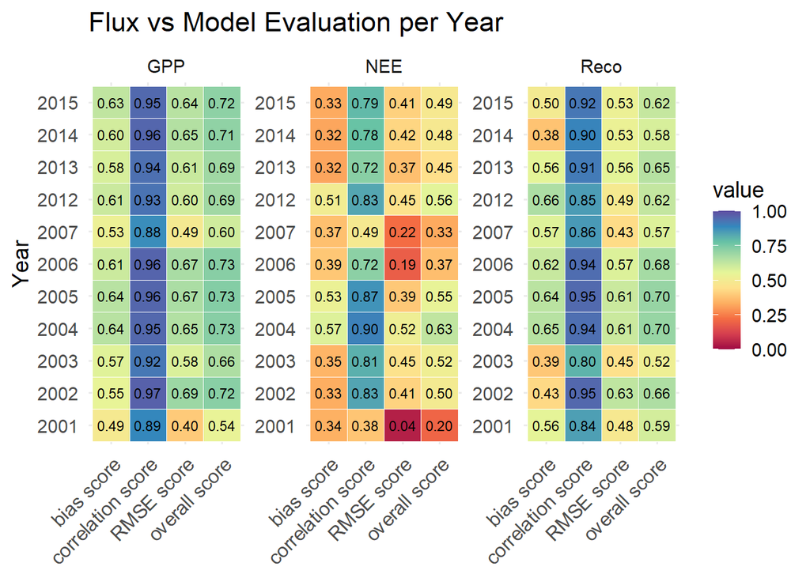

```r
# Calculate overall metric from yearly results
metric_summary <- metric_df %>%
  group_by(site, variable, metric) %>%
  summarise(
    value = mean(value, na.rm = TRUE),
    .groups = "drop"
  )

# plot interannual metrics
metric_df_sub <- subset(metric_df, metric %in% c("bias score", "correlation score",
                                                 "RMSE score", "overall score"))

metric_df_sub$metric <- factor(metric_df_sub$metric,
                               levels = c("bias score", "correlation score",
                                          "RMSE score", "overall score"))

ggplot(metric_df_sub, aes(x = metric, y = factor(year), fill = value)) +
  geom_tile(color = "white") +
  geom_text(aes(label = sprintf("%.2f", value)), size = 3) +
  scale_fill_gradientn(colors = brewer.pal(n = 10, name = "Spectral"), limits = c(0, 1)) +
  facet_wrap(~ variable, scales = "free", ncol = 3) +
  my_theme +
  labs(title = "Flux vs Model Evaluation per Year",
       x = NULL, y = "Year") +
  theme(axis.text.x = element_text(angle = 45, hjust = 1))
```

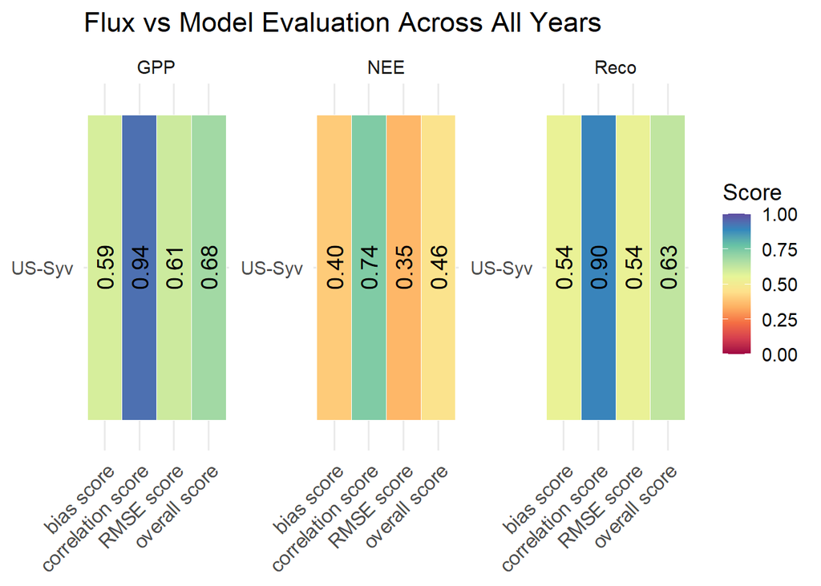

```r
#plot overall metric
scores <- c("bias score", "correlation score", "RMSE score", "overall score")

metric_summary_sub <- subset(metric_summary, metric %in% scores)

# Order metrics nicely
metric_summary_sub$metric <- factor(
  metric_summary_sub$metric,
  levels = c("bias score", "correlation score", "RMSE score", "overall score")
)

# Tile plot of mean scores across years
ggplot(metric_summary_sub, aes(x = metric, y = site, fill = value)) +
  geom_tile(color = "white") +
  geom_text(aes(label = sprintf("%.2f", value)), size = 5, angle = 90) +
  scale_fill_gradientn(colors = brewer.pal(n = 10, name = "Spectral"), limit = c(0, 1), name = "Score") +
  facet_wrap(~ variable, scales = "free", ncol = 3) +
  my_theme +
  labs(title = "Flux vs Model Evaluation Across All Years",
       x = NULL, y = NULL) +
  theme(axis.text.x = element_text(angle = 45, hjust = 1))
```

```r
#plot_save <- "model_scoring_GPP_NEE.png"
#ggsave(filename = plot_save, dpi = 500)
```

# Optional: evaluate flux vs model per month (across years); are there months when the model and flux tower agree more?

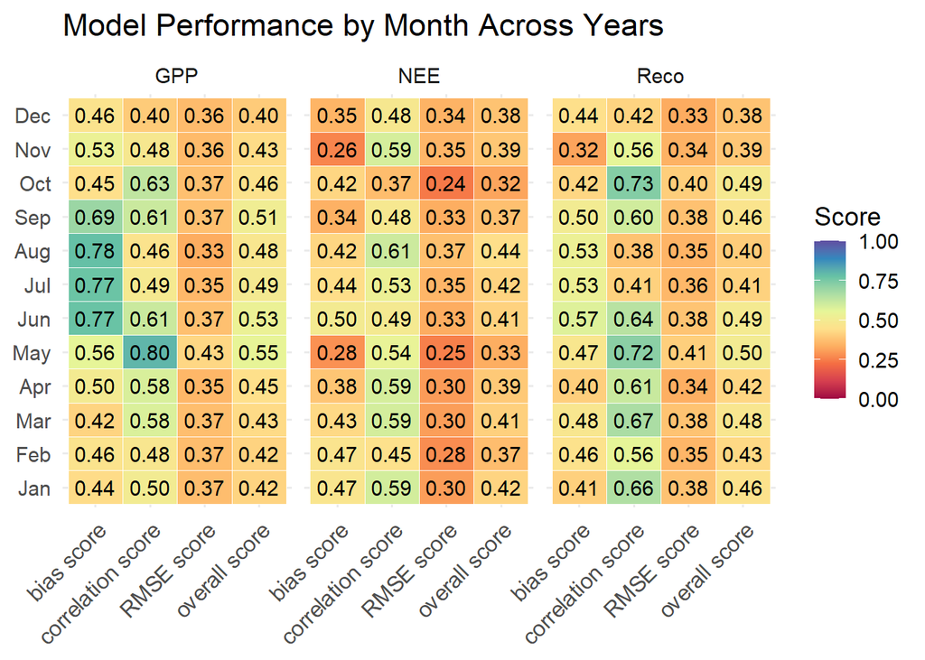

```r
# Variables to evaluate
variable_list <- c("GPP", "NEE", "Reco")
all_monthly_metrics <- list()  # to store results

months_to_evaluate <- sort(unique(df.combined_sub$month.x))

for (variable_run in variable_list) {
  for (month_val in months_to_evaluate) {

    # Subset model and observation data for each month across all years
    model <- subset(df.combined_sub, data_type == "Model" & flux_type == variable_run & month.x == month_val)
    obs   <- subset(df.combined_sub, data_type == "Tower" & flux_type == variable_run & month.x == month_val)

    # Skip if data is missing
    if (nrow(model) == 0 || nrow(obs) == 0 || all(is.na(model$value)) || all(is.na(obs$value))) next

    norm_sd <- sd(model$value, na.rm = TRUE) / sd(obs$value, na.rm = TRUE)
    S_corr  <- (1 + cor(model$value, obs$value, use = "complete.obs", method = "pearson")) / 2
    bias    <- model$value - obs$value
    rmse    <- sqrt(mean((model$value - obs$value)^2, na.rm = TRUE))

    e_bias  <- ifelse(abs(obs$value) > 0, abs(model$value - obs$value) / abs(obs$value), NA)
    S_bias  <- exp(-1 * e_bias)
    S_bias[!is.finite(S_bias)] <- NA
    domain_S_bias <- mean(S_bias, na.rm = TRUE)

    model_anom <- model$value - mean(model$value, na.rm = TRUE)
    obs_anom   <- obs$value   - mean(obs$value, na.rm = TRUE)
    crmse      <- sqrt(mean((model_anom - obs_anom)^2, na.rm = TRUE))
    crms       <- sqrt(mean(obs_anom^2, na.rm = TRUE))
    e_rmse     <- crmse / crms
    S_rmse     <- exp(-1 * e_rmse)

    S <- (domain_S_bias + 2 * S_rmse + S_corr) / 4

    metric <- c("tower mean", "tower SD", "model mean", "model SD", "SD norm.", "bias", "RMSE",
                "correlation score", "bias score", "RMSE score", "overall score")

    model_scores <- c(
      mean(obs$value, na.rm = TRUE), sd(obs$value, na.rm = TRUE),
      mean(model$value, na.rm = TRUE), sd(model$value, na.rm = TRUE),
      norm_sd, mean(bias, na.rm = TRUE), rmse,
      S_corr, domain_S_bias, S_rmse, S
    )

    score_df <- data.frame(site = site_name, month = month_val, variable = variable_run,
                           metric = metric, value = model_scores)

    all_monthly_metrics[[paste0(variable_run, "_", month_val)]] <- score_df
  }
}

# Combine into final table
monthly_metric_df <- do.call(rbind, all_monthly_metrics)
row.names(monthly_metric_df) <- NULL

# Subset to plot only key scoring metrics
scores <- c("bias score", "correlation score", "RMSE score", "overall score")

monthly_metric_plot_df <- subset(monthly_metric_df, metric %in% scores)

# Order metrics
monthly_metric_plot_df$metric <- factor(
  monthly_metric_plot_df$metric,
  levels = c("bias score", "correlation score", "RMSE score", "overall score")
)

# Add month name labels if needed
monthly_metric_plot_df$month <- factor(monthly_metric_plot_df$month,
                                       levels = 1:12,
                                       labels = month.abb)

# Plot
ggplot(monthly_metric_plot_df, aes(x = metric, y = month, fill = value)) +
  geom_tile(color = "white") +
  geom_text(aes(label = sprintf("%.2f", value)), size = 4) +
  scale_fill_gradientn(colors = brewer.pal(10, "Spectral"), limit = c(0, 1), name = "Score") +
  facet_wrap(~ variable, ncol = 3) +
  my_theme +
  labs(title = "Model Performance by Month Across Years", x = NULL, y = NULL) +
  theme(axis.text.x = element_text(angle = 45, hjust = 1))
```

- Use this part to read data from local drive
- Read data from local drive

```r
# # read flux data
# {
#   # please modify to your own local working directory
#   project_dir = ("G:/My Drive/FLUX-LSM workshop/US-Syv/")
#   setwd(paste0(project_dir, "AMF_US-Syv_FLUXNET_SUBSET_2001-2023_4-6"))
#   # read in daily flux data
#   df.flux = fread("AMF_US-Syv_FLUXNET_SUBSET_DD_2001-2023_4-6.csv")
#   # covert -9999 to NA
#   df.flux <- df.flux %>%
#     mutate(across(everything(), ~na_if(. , -9999)))
#   df.flux <- df.flux %>% # add more time variables
#     mutate(
#       TIMESTAMP = ymd(TIMESTAMP),
#       year = year(TIMESTAMP),
#       month = month(TIMESTAMP),
#       date = as.Date(TIMESTAMP),
#       doy = yday(TIMESTAMP)
#     )
# }
#
# # read model output
# {
#   setwd(project_dir)
#   # Open the NetCDF file
#   nc <- nc_open("ELM_output_US_Syv.nc")
#
#   # Extract time (mcdate)
#   mcdate <- ncvar_get(nc, "mcdate")
#   data_list <- lapply(vars_to_extract, function(var) ncvar_get(nc, var))
#
#   # Combine into data frame
#   df.model <- data.frame(mcdate = mcdate)
#   for (i in seq_along(vars_to_extract)) {
#     df.model[[vars_to_extract[i]]] <- data_list[[i]]
#   }
#
#   # Close NetCDF file
#   nc_close(nc)
#
#   # modify time variables
#   df.model <- df.model %>%
#     mutate(
#       mcdate = ymd(mcdate),
#       year = year(mcdate),
#       month = month(mcdate),
#       date = as.Date(mcdate),
#       doy = yday(mcdate)
#     )
#
#   }
#
# # combine flux data and model output
# df.model = df.model[df.model$year >=2001, ] # please change to the start year of flux measurement for you study site
# df.combined = left_join(df.model, df.flux)
#
# names(df.combined)
```